# RMarkdown Assignment

## Plot maps

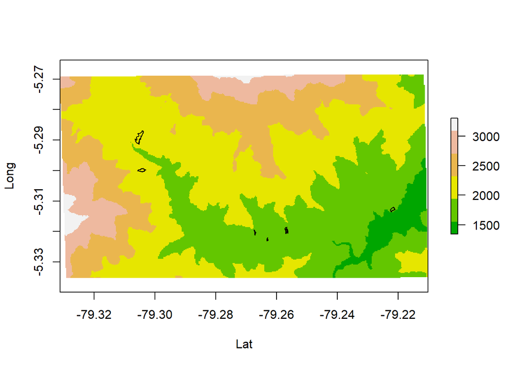

```r
## Plot polygons over elevation map
myCol <- terrain.colors(6)
plot(elev, xlab="Lat", ylab="Long", col=myCol)
plot(polygons_sp, cex = 0.5, add=TRUE)
```

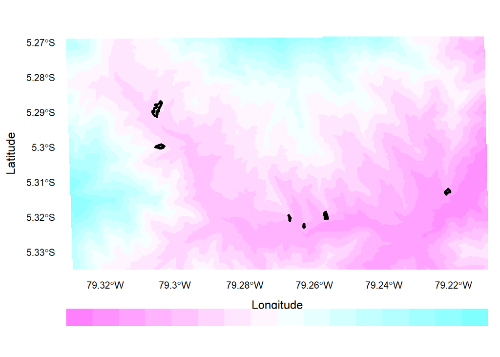

```r
levelplot(elev,
          margin=FALSE,
          colorkey=list(
            space='bottom',
            labels=list(at=-5:5, font=4)
          ),
          par.settings=list(
            axis.line=list(col='transparent')
          )) +
  layer(sp.polygons(polygons_sp, lwd=3))
```

## What did you learn?

The use of spatial analysis to plot dataset offer more advantage that the traditional use of Gis programs. It is possible to change the background of the map, improving the color by using different resources for color palette (e.g., terrain, colors, RColorBrewer). Finally, the aesthetic function allows modifying many parameters of maps, as we noticed in the comparison of both plots. In the examples, the plots are not the final product because they need to be resized for improving the visualization of bracken fern polygons. Likewise, both require names in the color scale of the legend.